# Tumor clonal structure pipeline

WU Fengyuan[^1]

2021/11/8

## Overview

This is the last part of cancer genomic training, we will use almost all the tools introduced previously to infer tumor clonal structure and construct a clone tree. The results of these tools will be used in this part: GATK toolkit, bcftools, SignatureAnalyzer, Sequenza, MutsigCV, PyClone-VI, Citup.  
PyClone-VI is a computationally efficient Bayesian statistical method for inferring the clonal population structure of cancers. The results of PyClone-VI include tumor clones and its celluar prevalence. PyClone was designed to analysis a samll panel of deeply sequenced mutations, while PyClone-VI could perform structure inference on a large amount of mutations at a faster speed.  
Citup is a tool for estimating the clone phylogeny and clonal genotypes for deep sequencing of SNVs in multiple tumour biopsies.

## Pipeline

**1.Input files**

| Files | Description |
| --- | --- |
| sample_1.vcf, sample_2.vcf, sample_3.vcf | VCF files generated by GATK toolkit, should only contain mutations with “PASS” QUAL. The samples are from same patient (different sampling timepoint or different regions). |
| sample_1.bam (Same for sample2 and sample3) | Bam files, can be generated and filtered by GATK toolkit. |
| sample_1_segments.txt, sample1_1_alternative_solutions.txt (Same for sample2 and sample3) | Output of Sequenza. |
| sample_list.txt | File cotain names of patients and samples in a row, tab delimited. Exp: “DT01 DT01_01”. |
| driver_genes.txt | A list of driver genes to be displayed on the tree, one gene a row. You can generate the list by MutSigCV or other tools or just refer to a published article. |
| reference.fasta | Human genome reference, should already been well indexed. |
| Funcotator resources | Resoucrces to run funcotator, same as files described in Mutect2 pipeline. |
| signature_weighted_maf.tsv | The output of supervised NMF. The vcf files described above can be used to generate this file with SignatureAnalyzer. |

**1.Take union set of mutations, generate mpileup files and annotate the union files**

```r
## Shell
## bcftools support regular expressions.

cat ../sample_list.txt|awk -F '\t' '{print $1}'|uniq|while read line
do
bcftools merge ${line}_*.vcf.gz -Ov --force-samples -o ${line}_union.vcf
done

cat ../sample_list.txt|awk -F '\t' '{print $1,$2}'|while read patient region
do
bcftools mpileup -R ${patient}_union.vcf -I -a FORMAT/AD -Ov \
-f reference.fasta \
-o ${region}_mpileup.vcf \
${region}.bam
done

cat ../sample_list.txt|awk -F '\t' '{print $1}'|uniq|while read line
do
gatk Funcotator \
--variant ${line}_union.vcf \
--reference reference.fasta \
--ref-version hg19 \
--data-sources-path funcotator_dataSources.v1.6.20190124s \
--output ${line}_annot.vcf \
--output-file-format VCF
done
```

**2.Prepare PyClone-VI input file**

```r
## R

library(data.table)

## Read VCF and sequenza files and reformat.
input=function(union_mat,SNV="",CNV="",CELL="",region=""){
maf=read.table(SNV,sep="\t")
  union_mat$chr=factor(union_mat$chr,labels=levels(maf$V1))
  t_count=lapply(strsplit(as.character(maf$V10),split=":"),function(x)(x[2]))
  t_count=do.call(rbind,lapply(t_count,function(x){unlist(strsplit(x,split=","))[1:2]}))
  maf=data.frame(sample_id=region,
                   ref_counts=t_count[,1],
                   alt_counts=t_count[,2],
                   chr=maf$V1,
                   start=maf$V2,
                   end=maf$V2+nchar(as.character(maf$V4))-1,
                   ref=maf$V4,
                   mut=maf$V5,
                   row.names=NULL)
  maf=merge(maf,union_mat,by=c("chr","start"))
  maf=data.table(maf,key=c("chr","start","end"))
  maf$normal_cn=apply(maf,1,function(x){if(x[4] %in% c("X","Y")){return(1)}else{return(2)}})
  seg=read.table(CNV,sep="\t",header=T)
  seg=data.table(chr=seg$chromosome,
               start=seg$start.pos,
               end=seg$end.pos,
               major_cn=seg$A,
               minor_cn=seg$B,
               key=c("chr","start","end"))
  maf=foverlaps(maf,seg,by.y=c("chr","start","end"))
  cell=read.table(CELL,header=T,sep="\t")
  cell=cell[1,1]
  maf=data.table(
               mutation_id=paste(maf$chr,maf$i.start,maf$mut.y,maf$gene_symbol,sep=":"),
               sample_id=maf$sample_id,
               ref_counts=maf$ref_counts,
               alt_counts=maf$alt_counts,
               normal_cn=maf$normal_cn,
               major_cn=maf$major_cn,
               minor_cn=maf$minor_cn,
               tumour_content=cell)
  maf=maf[!which(is.na(maf$major_cn)),]
return(maf)}

## Merge matrix generated by input funcation and annotate gene symbols.
output=function(sample_list,snv_path,cnv_path,snv_suffix,cnv_suffix,cell_suffix,union_suffix){
  sample_list=read.table(sample_list,header=F)
  sample_list$snv=paste0(snv_path,sample_list$V2,snv_suffix)
  sample_list$cnv=paste0(cnv_path,sample_list$V2,cnv_suffix)
  sample_list$cell=paste0(cnv_path,sample_list$V2,cell_suffix)
  sample_list=split(sample_list,factor(sample_list$V1))
  for(i in 1:length(sample_list)){
  union_mat=read.table(paste0(snv_path,names(sample_list)[i],union_suffix),sep="\t",quote="")
  gene_symbol=do.call(c,lapply(strsplit(as.character(union_mat$V8),split="[[|]"),function(x){x[2]}))
  union_mat=data.frame(chr=union_mat$V1,start=union_mat$V2,mut=union_mat$V5,gene_symbol=gene_symbol)
  mat=do.call(rbind,apply(sample_list[[i]],1,function(x){
    input(union_mat=union_mat,SNV = x[3],CNV = x[4],CELL=x[5],region = x[2])}))
  write.table(mat,paste0(sample_list[[i]][1,1],"_pyclone.txt"),quote=FALSE,sep="\t",row.names = FALSE)
  }
}

output(sample_list="sample_list.txt",
       snv_path="./snv/", ## The vcf files are stored in this directory.
       cnv_path="./cnv/", ## The sequenza output files are stored in this directory.
       snv_suffix="_mpileup.vcf",
       cnv_suffix="_segments.txt",
       cell_suffix="_alternative_solutions.txt",
       union_suffix="_annot.vcf")
```

**3. Run PyClone**

```r
## Shell

for patienct in $(cat sample_list.txt|awk -F '\t' '{print $1}'|uniq)
do
pyclone-vi fit -i ${patient}_pyclone.txt -o ${patient}.h5 -c 40 -d binomial -r 100
pyclone-vi write-results-file -i ${patient}.h5 -o ${patient}.tsv
done
```

**4.Prepare Citup input files**

```r
## R

library(dplyr)
citup_input=function(file=""){
  mat=read.table(file,sep="\t",header=T)
  info=split(mat,factor(mat$sample_id))[[1]][3]
  info=table(info)
  info=as.integer(names(info[which(info>=5)])) ##Exclude clones contain too few mutations.
  index=which(mat$cluster_id %in% info)
  mat=mat[index,]

  sam=as.character(mat$sample_id)
  sample=unlist(strsplit(sam,split="_"))[1]
  clu=factor(mat$cluster_id,labels = 0:(length(info)-1))
  mat$cluster_id=clu
  mat_ci=split(mat,factor(mat$sample_id))
  if(length(levels(clu))<2){
    print(paste0(sample," has not enougth clones"))
  }else{
  clu=mat_ci[[1]][3]
  clu=unique(clu)
  write.table(mat,paste0(sample,"_filter.txt"),sep="\t",quote=FALSE,row.names = F)
  mat_ci=do.call(cbind,lapply(mat_ci,select,cellular_prevalence))
  mat_ci=mat_ci[!duplicated(mat_ci),]
    write.table(mat_ci,paste0(sample,"_citup_input.txt"),sep="\t",quote=FALSE,col.names = F,row.names = F)
    write.table(clu,paste0(sample,"_citup_cluster.txt"),col.names = F,quote=FALSE,row.names = F)
  }
}

pyclone_path="./result/" ## PyClone-VI Output are stored in this directory.
sample_list=read.table("sample_list.txt",header=F)
sample_list=paste0(unique(sample_list$V1),".tsv")
for(file in sample_list){
  citup_input(file=paste0(pyclone_path,file))
}
```

**5.Run Citup**

```r
## Shell

for patient in $(ls *_cluster.txt|awk -F '_' '{print $1}'|uniq)
do
nodes=$(cat ${patient}_citup_cluster.txt|uniq|wc -l)
## The --max_nodes and --min_nodes are set to avoid multiple citup  clusters are mapped to same pyclone cluster or some pyclone clustersa are not included in citup results.
run_citup_qip.py --submit local --max_nodes ${nodes} --min_nodes ${nodes} --tmpdir ${sample}_tmp --maxjobs 24  ${patient}_citup_input.txt ${patient}_citup_cluster.txt ${patient}_citup_result.h5
done
```

**6.Draw a clone tree**

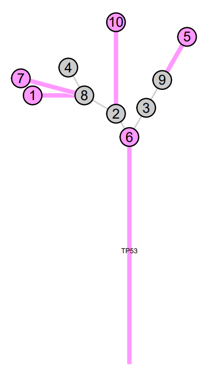

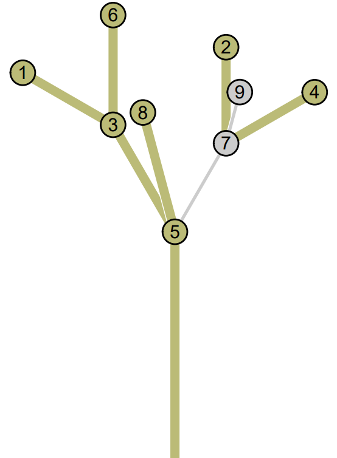

```r
## R script
## This is a simplified plotting script, you can customized the tree by editing clonevol scripts.
## The branch color indicates the dominant mutation process in this clone. Grey means no dominant mutation process or no enough mutations (15 here).
## Mutations in driver genes will be marked on corresponding branches.

library(rhdf5)
library(dplyr)
library(clonevol)

clonevol_file=function(pyclone_file,citup_file,sig_file,driver,patient){
  ##read pyclone results file and annotate drivers
  mat=read.table(pyclone_file,sep="\t",header=T)
  info=data.frame(do.call(rbind,strsplit(mat$mutation_id,split=":")))
  colnames(info)=c("Chromosome","Position","ALT","gene")
  info=data.frame(info,sample=mat$sample_id,cluster=mat$cluster_id)
  info$Position=as.numeric(info$Position)
  mat=split(mat,factor(mat$sample_id))
  cluster=(mat[[1]]$cluster_id)+1
  gene=do.call(rbind,strsplit(mat[[1]]$mutation_id,split=":"))[,4]
  is.driver=ifelse(gene %in% driver,"TRUE","FALSE")
  sample=names(mat)
  mat=do.call(cbind,lapply(mat,select,cellular_prevalence))
  colnames(mat)=paste0(sample,".ccf")
  mat=data.frame(cluster=cluster,gene=gene,is.driver=is.driver,mat)
  write.table(mat,paste0(patient,"_variants.tsv"),sep="\t",quote=FALSE,row.names = FALSE)

  ##read signatureanalyzer result file then annotate mutation process
  maf=read.table(sig_file,sep="\t",header=T) %>% select(-1,-c(4:8),-c(11:17))
  signatures=colnames(maf)[5:dim(maf)[2]]
  signatures=apply(maf,1,function(x){signatures[which.max(x[5:length(x)])]})
  maf=data.frame(maf[,1:4],signatures)
  info=left_join(info,maf,by=c("Chromosome"="Chromosome","Position"="Start_position","sample"="Tumor_Sample_Barcode","ALT"="Tumor_Seq_Allele2"))
  info$signatures[which(is.na(info$signatures))]="nosig"
  info=info[,6:7]
  info=table(info$cluster,info$signatures)
  sig_col=get.clonevol.colors(dim(info)[2])
  k=which(colnames(info)=="nosig")
  names(sig_col)=c("nosig",colnames(info)[-k])
  info=apply(info,1,function(x){
    s=x[-k]
    if(sum(x)<15*length(sample)){
      return(c(sig_col["nosig"],0.2))
    }else if(max(s)/sum(s)>=0.5){
      return(c(sig_col[colnames(info)[-k][which.max(s)]],0.5))
    }else{
      return(c(sig_col["nosig"],0.2))
    }
  })

  ##read citup file and reformat
  tree=h5read(citup_file, "/results")
  opt=tree$optimal$index[1]
  tree=h5read(citup_file, paste0("/trees/",opt))
  adj=t(tree$adjacency_list$block0_values)
  pyc_cor=tree$cluster_assignment
  clone=factor(c(0,adj[,2]),levels = pyc_cor$values,labels=pyc_cor$index)
  clone=as.numeric(clone)
  parent=factor(adj[,1],levels = pyc_cor$values,labels=pyc_cor$index)
  parent=c(-1,as.numeric(parent))
  clone_freq=mat[!duplicated(mat),][,-1]
  sample.with.nonzero.cell.frac.ci=apply(clone_freq,1,function(x){paste(sample[x>0],collapse = ",")})
  sample.with.nonzero.cell.frac.ci=""
  tree=data.frame(clone,parent,sample.with.nonzero.cell.frac.ci)
  tree=tree[order(tree$clone),]
  tree$color=info[1,]
  tree$branch.width=info[2,]
  write.table(tree,paste0(patient,"_tree.tsv"),sep="\t",quote = FALSE,row.names = FALSE)
}

clonevol_file(pyclone_file = "patient1.tsv",
              citup_file = "patient1_citup_result.h5",
              sig_file = "signature_weighted_maf.tsv",
              patient="patient1",
              drivers=c("TP53","CTNNB1","KEAP1","C16orf62","MLL4","RAC2"))
y=import.tree("patient_tree.tsv","patient_variants.tsv")
y = convert.consensus.tree.clone.to.branch(y, branch.scale = 'sqrt')
y = transfer.events.to.consensus.trees(y,
                                        y$variants[y$variants$is.driver,],
                                       cluster.col.name = "cluster",
                                        event.col.name = "gene")
merged_trees=y$matched$merged.trees[[1]]
y$matched$merged.trees[[1]]=merged_trees[order(merged_trees$branches,decreasing = T),]
pdf('tree.pdf', width = 3, height = 5, useDingbats = FALSE)
plot.tree(y$matched$merged.trees[[1]],angle=30,node.size = 2,node.label.size = 0.7)
dev.off()
```

## Results and Q&A

**1.Why take union of mutations**

Simply merging vcf files will result in few mutations, and they are likely all clonal.  
Some mutations are not included in some samples’ vcf files but there are still some reads support such mutations. They are not included because their frequency is low in some samples but such mutations are required for PyClone-VI.

**2.PyClone-VI output**

| Columns | Description |
| --- | --- |
| mutation_id | Mutation identifier as used in the input file. |
| sample_id | Unique identifier for the sample as used in the input file. |
| cluster_id | Most probable cluster or clone the mutation was assigned to. |
| cellular_prevalence | Proportion of malignant cells with the mutation in the sample. This is also called cancer cell fraction (CCF) in the literature. |
| cellular_prevalence_std | Standard error of the cellular_prevalence estimate. |
| cluster_assignment_prob | Posterior probability the mutation is assigned to the cluster. This can be used as a confidence score to remove mutations with low probability of belonging to a cluster. |

**3.Citup Installation**

Citup is developed under python 2.7, you can install it with conda.

**4.AttributeError: ‘GMM’ object has no attribute ‘covariances_’ or AttributeError: ‘module’ object has no attribute ‘GaussianMixture’**

Refer to the log file in tmp directory by citup, you may find such errors. In the new versions from 0.18 onwards, GMM has been deprecated and GaussianMixture.  
To fix this, unzip citup-0.1.0-py2.7.egg at path mentioned in the log file. Replace “covariances_” with “covars_” and “GaussianMixture” with “GMM” in the tasks.py. Then recompressed the file.

**4.Citup Input**

The github page of Citup claims the input file should be one mutation per row. But with such input file, the running time will be so long. Mutations in same cluster have same frequency, one cluster per row will not lose information or affect results but will speed up a lot.

**5.The Running time of Citup is too long**

The topologies of tree incresea exponentially with the number of clones. When the number of clones exceed 10, the running time is unbearable. So just take top 10 clones with most mutations of PyClone-VI output to run Citup.

**6.Citup output**

| Names | Description |
| --- | --- |
| /results/optimal | tree ids ordered by bic score, the first one is the most optimal tree. |
| trees/{tree_solution}/cluster_assignment | Correspondence between pyclone clusters and citup clusters. The first row is pyclone cluster, the second row is citup clusters. |
| trees/{tree_solution}/adjacency_list | The structure of tree. The first row is parent, the second row is descendent. |
| /trees/{tree_solution}/clone_freq | Clone frequency in each sample. |
| /trees/{tree_solution}/cluster_freq | Variant allele frequency in each sample. |

[^1]: Institute of Zoology, CAS wufengyuan@ioz.ac.cn